# Esto es un título de primer nivel

## 1. Esto es un título de segundo nivel

## 2. Formateo de texto

Esto es texo normal

**Esto se mostrará en negrita**

*Esto se mostrará en cursiva*

Esto se mostrará tachado

> Esto se mostrará como una cita

## 3. Listas

Listas con números:

1. Primero
2. Segundo
3. Tercero

Listas con bullets:

- Primero
- segundo
- Tercero

Mas listas:

1. Primero
   - 1.1
   - 1.2
2. Segundo
   - a
   - b
3. Tercero

### Sub-indices y ..

Un superíndice: Y<sup>2</sup>

Un subíndice: Y<sub>2</sub>

### Imágenes

Para mostrar una imágen basta con:

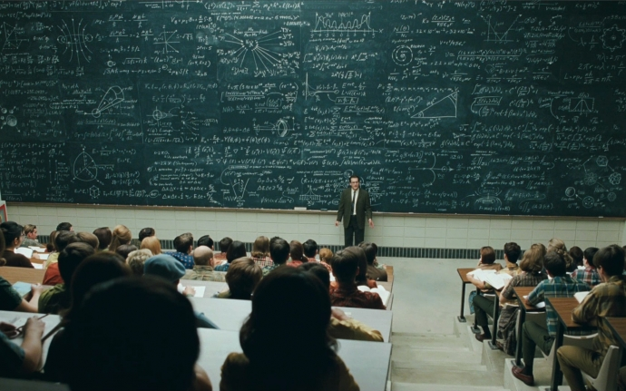

También podríamos haberlo hecho así (da un poco más flexibilidad):

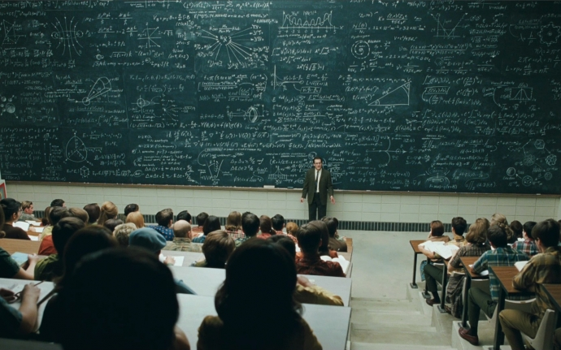

### Formulas

Las formulas hay que escribirlas en Latex. Yo no sé mucho Latex, pero hay editores que facilitan mucho el trabajo: preguntad al profe!!

Una fórmula dentro del texto se escribiría así: $E = mc^{2}$ ; es decir, enmarcándola por `$`

Si quieres la formula ella sola hay que poner dos `$$`:

$$E = mc^{2}$$

### Hyperlinks

Esto es un hyperlink: http://www.wikipedia.es

Pero es mejor ponerlo así: [enlace a la Wikipedia](http://www.wikipedia.es)

### Notas al pie de página

Para poner notas al pie has de poner [^1]

### Tablas

Habrá un tutorial especifico para tablas, pero lo más básico y sencillo es con la función `kable()`:

```r
knitr::kable(summary(iris))
```

|  | Sepal.Length | Sepal.Width | Petal.Length | Petal.Width | Species |
| --- | --- | --- | --- | --- | --- |
|  | Min. :4.300 | Min. :2.000 | Min. :1.000 | Min. :0.100 | setosa :50 |
|  | 1st Qu.:5.100 | 1st Qu.:2.800 | 1st Qu.:1.600 | 1st Qu.:0.300 | versicolor:50 |
|  | Median :5.800 | Median :3.000 | Median :4.350 | Median :1.300 | virginica :50 |
|  | Mean :5.843 | Mean :3.057 | Mean :3.758 | Mean :1.199 | NA |
|  | 3rd Qu.:6.400 | 3rd Qu.:3.300 | 3rd Qu.:5.100 | 3rd Qu.:1.800 | NA |
|  | Max. :7.900 | Max. :4.400 | Max. :6.900 | Max. :2.500 | NA |

## 5. Aún más cosas

Hay más cosas, como referencias bibliográficas, pero ya será para el segundo curso de R.

A pesar de que Markdown permite formatear el texto, en ciertos sentidos es limitado; pero si quieres aún más flexibilidad en el output, tendrás que aprender html y mejor html+CSS.

Algunos ejemplos:

1. Si quieres introducir un párrafo en otro color tendrás que hacerlo en html

Esto se mostrará en ROJO!!

2. si quieres centrar un párrafo.

Este párrafo irá centrado

3. Una pagina web

[interactive chart not shown]

4. Un vídeo

[video not shown]

[^1]: esto es una nota al pie.